# Data preparation for extended ICE analysis

Stephanie Evert & the QuanTOR team

22 January 2025

This script has been adapted from the reproduction materials provided by Neumann & Evert (2021) at https://www.stephanie-evert.de/PUB/NeumannEvert2021/, in particular the script `prepare_data.Rmd` from ZIP archive [`analysis_scripts.zip`](https://www.stephanie-evert.de/PUB/NeumannEvert2021/data/analysis_scripts.zip).

# 1 English texts from the International Corpus of English (nine components)

```r
suppressMessages(library(data.table))
library(ggplot2)
library(ggExtra)
library(grid) # needed to work around bug in ggMarginal
library(seriation)
library(colorspace)
library(kableExtra)
library(corpora)
```

## 1.1 Data set and pre-processing

```r
Meta <- fread("ice_metadata.csv", encoding="UTF-8")
setkey(Meta, id)
Features <- fread("ice_features.tsv", encoding="UTF-8")
setkey(Features, id)
```

Occasionally, ICE components include texts that consist only of extra-corpus material. As a result, we have metadata information for these text but no feature vectors. Currently, there is a single case in our data:

```r
Meta[!(id %in% Features$id)]
```

```
## Key: <id>
##                 id variety    mode  format                    type
##             <char>  <char>  <char>  <char>                  <char>
## 1: icenz_w2b-037_5   icenz written printed informational (popular)
##              category
##                <char>
## 1: learned technology
```

We therefore need to reduce the `Meta` table to existing texts, at the same time ensuring that we have metadata information for all texts and there are no ID mismatches.

```r
stopifnot(all(Features$id %in% Meta$id))
Meta <- Meta[id %in% Features$id]
```

There are 8825 rows in both tables and the text IDs (`id`) match (TRUE). Since we index the data.tables by text ID, which automatically sorts them alphabetically, we cannot randomize the order of the rows as in previous analyses. We have also made sure that the IDs are unique: TRUE.

### 1.1.1 Normalization based on word counts

Note that relative frequencies in the feature vectors are based on *word counts* rather than token counts now. This was made possible by the new feature extraction pipeline using the `cwb-featex` tool (and by the fact that ICE is small enough so that the very inefficient query for word counts can still be executed).

### 1.1.2 Cleanup

First we check the data to see whether we have to clean it up:

- the feature `salutation_S` is excluded because it is extremely sparse (and hence produces extreme z-scores)
- the frequency of attributive adjectives (`atadj_W`) is highly correlated with the overall frequency of adjectives (`adj_W`), especially in English texts; we therefore use non-attributive (“predicative”) adjectives (`predadj_W`) rather than (`adj_W`)

```r
Features[, qw("salutation_S adj_W") := NULL]
```

We also discard 895 texts with less than 100 words or less than 10 sentences because the quantitative features will be too unreliable and are prone to create outliers in the multivariate analysis. Before we do so, let’s check whether this affects the sub-corpora in substantially different ways.

```r
to.discard <- Features[, !(word >= 100 & sent >= 10)]
res <- table(to.discard, Meta$variety)
print(res)
```

```
##
## to.discard icecan icegb icehk iceind iceire icejam icenz icephi icesing
##      FALSE    964   877  1110    672    817    904   814    885     887
##      TRUE     153   122   144     42     44    131    78    137      44
```

```r
print(round(100 * prop.table(res, margin=2), 2))
```

```
##
## to.discard icecan icegb icehk iceind iceire icejam icenz icephi icesing
##      FALSE  86.30 87.79 88.52  94.12  94.89  87.34 91.26  86.59   95.27
##      TRUE   13.70 12.21 11.48   5.88   5.11  12.66  8.74  13.41    4.73
```

For each component, we lose between 5% and 14% of the texts, which we consider acceptable. One of the first aims of QuanTOR is to extend GMA so that it can also be applied to such short texts.

We should also check whether certain text categories are affected particularly strongly by the exclusion of short texts.

```r
table(Meta$category, to.discard)
```

```
##                             to.discard
##                              FALSE TRUE
##   administrative/regulatory    160    6
##   broadcast discussions        214    5
##   broadcast interviews         117    1
##   broadcast news               368   26
##   broadcast talks              320   15
##   business letters             828  299
##   business transactions        104    0
##   class lessons                191    1
##   demonstrations               128    3
##   direct conversations         910    6
##   distance conversations       118    1
##   learned humanities           128    4
##   learned natural sciences     149    5
##   learned social sciences      138    3
##   learned technology           205   12
##   legal cross-examinations     114    0
##   legal presentations          118   11
##   novels/stories               213    8
##   parliamentary debates        101    2
##   popular humanities            90    1
##   popular natural sciences      96    1
##   popular social sciences       98    1
##   popular technology           107    0
##   press editorials             322   33
##   press news reports           749  140
##   skills/hobbies               203   10
##   social letters               566  148
##   speeches (not broadcast)     114    1
##   spontaneous commentaries     251  121
##   student examination essays   232   10
##   student untimed essays       154    6
##   unscripted speeches          324   15
```

```r
Features <- subset(Features, word >= 100 & sent >= 10)
Meta <- Meta[Features$id, ]
```

After cleanup, there are 7930 texts and 44 features in the data set, including sentence, token and word counts. The two tables are still consistent (TRUE).

## 1.2 Text categories

A revised set of text categories has been provided in file `text_categories.tsv`, which defines both category labels at three different layers of granularity (with 32, 20 and 12 categories) and the standard ordering of the categories.

```r
TextCat <- fread("text_categories.tsv", encoding="UTF-8")
```

We use this information to generate appropriate factor levels and colour coding for later visualisation. First check that there are no unexpected duplicates and full names, short labels and category codes match at every layer.

```r
has.distinct <- function (tbl, n=32)
  stopifnot(length(unique(do.call(paste, as.list(tbl)))) == n)
has.distinct(TextCat[, .(category)])
has.distinct(TextCat[, .(textcat32)])
has.distinct(TextCat[, .(short32)]) # combinations of name, short label
has.distinct(TextCat[, .(code32)])  # and code are necessarily unique
has.distinct(TextCat[, .(textcat20)], 20)
has.distinct(TextCat[, .(short20)], 20)
has.distinct(TextCat[, .(code20)], 20)
has.distinct(TextCat[, .(textcat20, short20, code20)], 20)
has.distinct(TextCat[, .(textcat12)], 12)
has.distinct(TextCat[, .(short12)], 12)
has.distinct(TextCat[, .(code12)], 12)
has.distinct(TextCat[, .(textcat12, short12, code12)], 12)
```

We now collect text category names, short labels and codes in the specified ordering (to be used as factor levels and for labeling visualisations). Note that the levels are aligned at each granularity, so it is easy to map between names, labels and codes. Similar vectors of levels are created for written vs. spoken mode, text format, and for the nine varieties (named to facilitate mapping the metadata table).

```r
types.variety <- qw("New Zealand, Jamaica, Hong Kong, India, Philippines, Singapore, Canada, Ireland, Great Britain", sep=",\\s*")
types.shortvar <- qw("NZ JAM HK IND PHI SIN CAN IRE GB")
names(types.variety) <- names(types.shortvar) <- qw("icenz icejam icehk iceind icephi icesing icecan iceire icegb")
types.mode <- qw("written spoken")
types.format <- qw("printed non-printed monologue dialogue")
types.textcat32 <- unique(TextCat$textcat32)
types.short32 <- unique(TextCat$short32)
types.code32 <- unique(TextCat$code32)
types.textcat20 <- unique(TextCat$textcat20)
types.short20 <- unique(TextCat$short20)
types.code20 <- unique(TextCat$code20)
types.textcat12 <- unique(TextCat$textcat12)
types.short12 <- unique(TextCat$short12)
types.code12 <- unique(TextCat$code12)
```

We also generate aligned rainbow colour vectors for the three layers of granularity, with short labels for easy lookup. For the less fine-grained categories, the colour of the “middle” sub-category is selected.

```r
col.vec <- rainbow_hcl(32, c = 80, l = 60)
rainbow.32 <- structure(col.vec, names=types.short32)
tmp <- TextCat[, .(col = col.vec[mean(.I)]), by=short20]
rainbow.20 <- structure(tmp$col, names=tmp$short20)
stopifnot(all.equal(names(rainbow.20), types.short20))
tmp <- TextCat[, .(col = col.vec[mean(.I)]), by=short12]
rainbow.12 <- structure(tmp$col, names=tmp$short12)
stopifnot(all.equal(names(rainbow.12), types.short12))
```

An overview table of the colour vectors shows that they are correctly aligned. It is also exported to a PDF file as a handy reference.

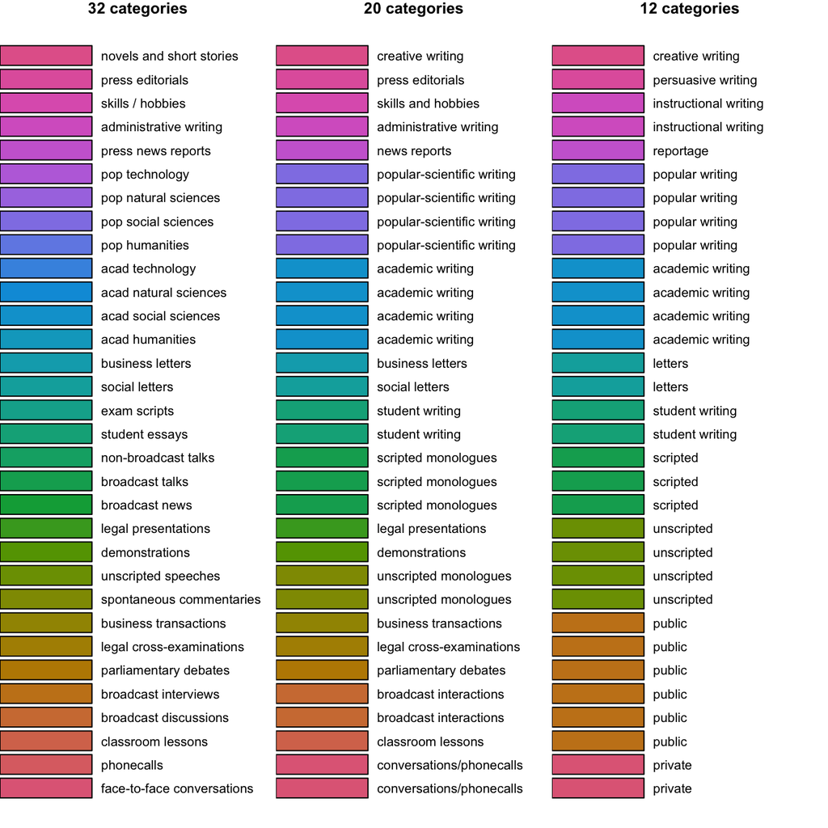

```r
par(mfrow=c(1, 3), mar=c(0,0,1,0))
mp <- barplot(rep(1, 32), col=rainbow.32, horiz=TRUE,
              xlim=c(0, 3), xaxt="n", main="32 categories")
text(1.1, mp, types.textcat32, adj=c(0, .5))
barplot(rep(1, 32), col=rainbow.20[TextCat$short20],
        horiz=TRUE, xlim=c(0, 3), xaxt="n", main="20 categories")
text(1.1, mp, TextCat$textcat20, adj=c(0, .5))
barplot(rep(1, 32), col=rainbow.12[TextCat$short12],
        horiz=TRUE, xlim=c(0, 3), xaxt="n", main="12 categories")
text(1.1, mp, TextCat$textcat12, adj=c(0, .5))
```

```r
invisible(dev.copy2pdf(file="pdf_journal/colour_key_textcat.pdf", out.type="cairo"))
```

## 1.3 Revise metadata

We can now merge the additional information into the Metadata table and remove meta variables that are no longer needed. Before the merge, we make sure that the `category` labels are identical for both data frames.

```r
stopifnot(setequal(TextCat$category, Meta$category))
Meta <- merge(Meta, TextCat, by="category")
Meta[, qw("category type") := NULL] # redundant columns
```

We also recode the language variety labels in long and short forms.

```r
Meta[, shortvar := types.shortvar[variety]]
Meta[, variety := types.variety[variety]]
```

We also have to make sure that `Meta` is still aligned with `Features` (by re-sorting on ID).

```r
setkey(Meta, id)
stopifnot(all.equal(Meta$id, Features$id))
```

Finally, all meta-variables are coded as factors with correct levels and ordering.

```r
Meta <- transform(
  Meta,
  variety = factor(variety, levels=types.variety),
  shortvar = factor(shortvar, levels=types.shortvar),
  mode = factor(mode, levels=types.mode),
  format = factor(format, levels=types.format),
  textcat32 = factor(textcat32, levels=types.textcat32),
  short32 = factor(short32, levels=types.short32),
  code32 = factor(code32, levels=types.code32),
  textcat20 = factor(textcat20, levels=types.textcat20),
  short20 = factor(short20, levels=types.short20),
  code20 = factor(code20, levels=types.code20),
  textcat12 = factor(textcat12, levels=types.textcat12),
  short12 = factor(short12, levels=types.short12),
  code12 = factor(code12, levels=types.code12))
```

## 1.4 Metadata distributions

Let us now take a look at the metadata categories. (NB: using `kbl()` and `kable_styling()` ensures that tables display reasonably well in RStudio notebooks running in dark mode)

```r
kbl(xtabs(~ textcat32 + shortvar, data=Meta)) |> kable_styling()
```

|  | NZ | JAM | HK | IND | PHI | SIN | CAN | IRE | GB |
| --- | --- | --- | --- | --- | --- | --- | --- | --- | --- |
| face-to-face conversations | 90 | 99 | 105 | 92 | 91 | 104 | 118 | 92 | 119 |
| phonecalls | 10 | 15 | 11 | 19 | 10 | 12 | 12 | 11 | 18 |
| classroom lessons | 20 | 22 | 22 | 20 | 20 | 17 | 28 | 20 | 22 |
| broadcast discussions | 20 | 21 | 23 | 20 | 20 | 22 | 47 | 20 | 21 |
| broadcast interviews | 10 | 12 | 13 | 12 | 11 | 14 | 22 | 10 | 13 |
| parliamentary debates | 14 | 10 | 9 | 12 | 10 | 10 | 15 | 10 | 11 |
| legal cross-examinations | 18 | 15 | 16 | 10 | 9 | 11 | 13 | 10 | 12 |
| business transactions | 10 | 12 | 10 | 10 | 15 | 11 | 12 | 11 | 13 |
| spontaneous commentaries | 22 | 40 | 20 | 21 | 20 | 26 | 26 | 23 | 53 |
| unscripted speeches | 36 | 32 | 51 | 30 | 31 | 35 | 34 | 30 | 45 |
| demonstrations | 11 | 11 | 12 | 13 | 29 | 13 | 11 | 11 | 17 |
| legal presentations | 11 | 17 | 13 | 10 | 20 | 10 | 14 | 11 | 12 |
| broadcast news | 57 | 29 | 43 | 32 | 46 | 41 | 65 | 29 | 26 |
| broadcast talks | 36 | 21 | 45 | 21 | 25 | 47 | 64 | 20 | 41 |
| non-broadcast talks | 13 | 10 | 17 | 11 | 11 | 14 | 16 | 10 | 12 |
| student essays | 15 | 40 | 13 | 19 | 16 | 14 | 14 | 11 | 12 |
| exam scripts | 29 | 26 | 11 | 54 | 31 | 26 | 13 | 13 | 29 |
| social letters | 43 | 93 | 107 | 25 | 57 | 67 | 57 | 50 | 67 |
| business letters | 79 | 111 | 133 | 16 | 112 | 104 | 73 | 104 | 96 |
| acad humanities | 11 | 11 | 20 | 12 | 16 | 12 | 19 | 16 | 11 |
| acad social sciences | 12 | 12 | 27 | 12 | 19 | 10 | 16 | 20 | 10 |
| acad natural sciences | 11 | 23 | 20 | 13 | 21 | 15 | 19 | 17 | 10 |
| acad technology | 16 | 23 | 43 | 11 | 21 | 21 | 29 | 30 | 11 |
| pop humanities | 10 | 10 | 10 | 10 | 10 | 10 | 10 | 10 | 10 |
| pop social sciences | 11 | 10 | 16 | 11 | 10 | 10 | 10 | 10 | 10 |
| pop natural sciences | 10 | 9 | 12 | 11 | 10 | 14 | 10 | 10 | 10 |
| pop technology | 15 | 14 | 15 | 10 | 12 | 11 | 10 | 10 | 10 |
| press news reports | 95 | 67 | 117 | 57 | 84 | 59 | 96 | 95 | 79 |
| administrative writing | 14 | 20 | 21 | 11 | 12 | 47 | 9 | 15 | 11 |
| skills / hobbies | 13 | 24 | 27 | 23 | 26 | 23 | 24 | 33 | 10 |
| press editorials | 31 | 22 | 63 | 23 | 40 | 35 | 37 | 35 | 36 |
| novels and short stories | 21 | 23 | 45 | 21 | 20 | 22 | 21 | 20 | 20 |

```r
kbl(xtabs(~ textcat20 + shortvar, data=Meta)) |> kable_styling()
```

|  | NZ | JAM | HK | IND | PHI | SIN | CAN | IRE | GB |
| --- | --- | --- | --- | --- | --- | --- | --- | --- | --- |
| conversations/phonecalls | 100 | 114 | 116 | 111 | 101 | 116 | 130 | 103 | 137 |
| classroom lessons | 20 | 22 | 22 | 20 | 20 | 17 | 28 | 20 | 22 |
| broadcast interactions | 30 | 33 | 36 | 32 | 31 | 36 | 69 | 30 | 34 |
| parliamentary debates | 14 | 10 | 9 | 12 | 10 | 10 | 15 | 10 | 11 |
| legal cross-examinations | 18 | 15 | 16 | 10 | 9 | 11 | 13 | 10 | 12 |
| business transactions | 10 | 12 | 10 | 10 | 15 | 11 | 12 | 11 | 13 |
| unscripted monologues | 58 | 72 | 71 | 51 | 51 | 61 | 60 | 53 | 98 |
| demonstrations | 11 | 11 | 12 | 13 | 29 | 13 | 11 | 11 | 17 |
| legal presentations | 11 | 17 | 13 | 10 | 20 | 10 | 14 | 11 | 12 |
| scripted monologues | 106 | 60 | 105 | 64 | 82 | 102 | 145 | 59 | 79 |
| student writing | 44 | 66 | 24 | 73 | 47 | 40 | 27 | 24 | 41 |
| social letters | 43 | 93 | 107 | 25 | 57 | 67 | 57 | 50 | 67 |
| business letters | 79 | 111 | 133 | 16 | 112 | 104 | 73 | 104 | 96 |
| academic writing | 50 | 69 | 110 | 48 | 77 | 58 | 83 | 83 | 42 |
| popular-scientific writing | 46 | 43 | 53 | 42 | 42 | 45 | 40 | 40 | 40 |
| news reports | 95 | 67 | 117 | 57 | 84 | 59 | 96 | 95 | 79 |
| administrative writing | 14 | 20 | 21 | 11 | 12 | 47 | 9 | 15 | 11 |
| skills and hobbies | 13 | 24 | 27 | 23 | 26 | 23 | 24 | 33 | 10 |
| press editorials | 31 | 22 | 63 | 23 | 40 | 35 | 37 | 35 | 36 |
| creative writing | 21 | 23 | 45 | 21 | 20 | 22 | 21 | 20 | 20 |

```r
kbl(xtabs(~ textcat12 + shortvar, data=Meta)) |> kable_styling()
```

|  | NZ | JAM | HK | IND | PHI | SIN | CAN | IRE | GB |
| --- | --- | --- | --- | --- | --- | --- | --- | --- | --- |
| private | 100 | 114 | 116 | 111 | 101 | 116 | 130 | 103 | 137 |
| public | 92 | 92 | 93 | 84 | 85 | 85 | 137 | 81 | 92 |
| unscripted | 80 | 100 | 96 | 74 | 100 | 84 | 85 | 75 | 127 |
| scripted | 106 | 60 | 105 | 64 | 82 | 102 | 145 | 59 | 79 |
| student writing | 44 | 66 | 24 | 73 | 47 | 40 | 27 | 24 | 41 |
| letters | 122 | 204 | 240 | 41 | 169 | 171 | 130 | 154 | 163 |
| academic writing | 50 | 69 | 110 | 48 | 77 | 58 | 83 | 83 | 42 |
| popular writing | 46 | 43 | 53 | 42 | 42 | 45 | 40 | 40 | 40 |
| reportage | 95 | 67 | 117 | 57 | 84 | 59 | 96 | 95 | 79 |
| instructional writing | 27 | 44 | 48 | 34 | 38 | 70 | 33 | 48 | 21 |
| persuasive writing | 31 | 22 | 63 | 23 | 40 | 35 | 37 | 35 | 36 |
| creative writing | 21 | 23 | 45 | 21 | 20 | 22 | 21 | 20 | 20 |

```r
kbl(xtabs(~ mode + shortvar, data = Meta))    |> kable_styling()
```

|  | NZ | JAM | HK | IND | PHI | SIN | CAN | IRE | GB |
| --- | --- | --- | --- | --- | --- | --- | --- | --- | --- |
| written | 436 | 538 | 700 | 339 | 517 | 500 | 467 | 499 | 442 |
| spoken | 378 | 366 | 410 | 333 | 368 | 387 | 497 | 318 | 435 |

There is some imbalance in the number of text samples in the nine varieties and their distribution across text categories, but this is due to the design of and artefacts in the ICE corpora.

## 1.5 Text lengths

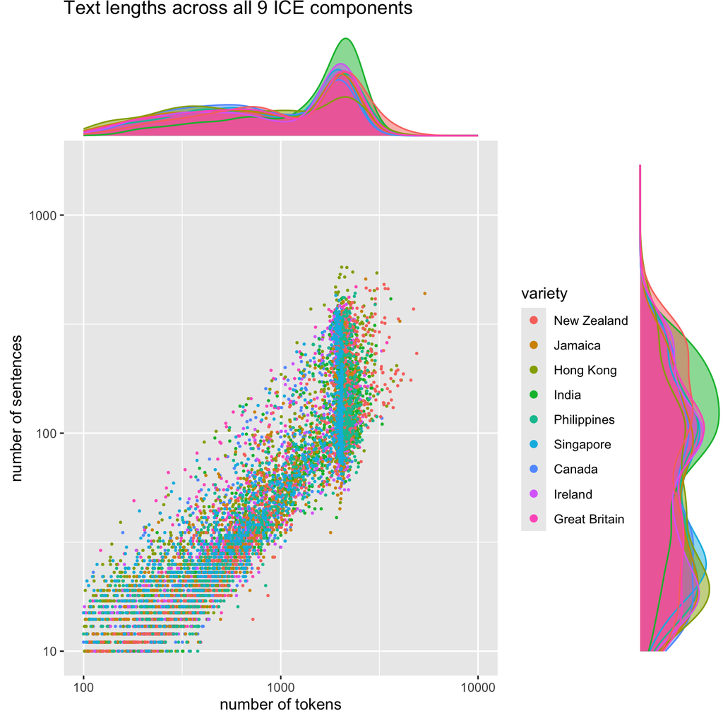

```r
grid.newpage()
tmp <- cbind(Features, Meta[, .(variety)])
p <- ggplot(tmp, aes(x=word, y=sent, col=variety)) +
  scale_x_log10(limits=c(100, 10000)) + scale_y_log10(limits=c(10, 1700)) +
  geom_point(cex=.4) + labs(x="number of tokens", y="number of sentences") +
  guides(colour = guide_legend(override.aes = list(size=2))) +
  labs(title="Text lengths across all 9 ICE components")
p <- ggMarginal(p, groupColour=TRUE, groupFill=TRUE)
grid.draw(p)
```

```r
invisible(dev.copy2pdf(file="pdf_journal/stats_textlength_by_variety.pdf", out.type="cairo"))
```

Also check how much text lengths differ between text categories.

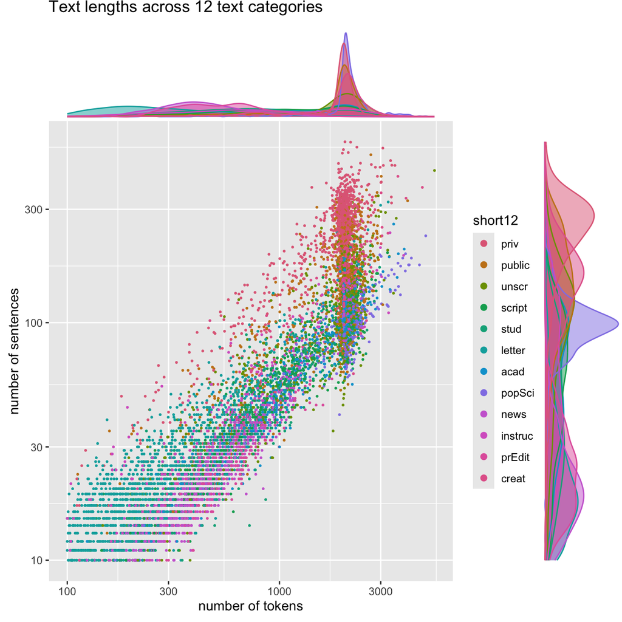

```r
grid.newpage()
tmp <- cbind(Features, Meta[, .(variety, short12)])
p <- ggplot(tmp, aes(x=word, y=sent, col=short12)) +
  scale_x_log10() + scale_y_log10() + scale_colour_manual(values=rainbow.12) +
  geom_point(size=.4) + labs(x="number of tokens", y="number of sentences") +
  guides(colour = guide_legend(override.aes = list(size=2))) +
  labs(title="Text lengths across 12 text categories")
p <- ggMarginal(p, groupColour=TRUE, groupFill=TRUE)
grid.draw(p)
```

```r
invisible(dev.copy2pdf(file="pdf_journal/stats_textlength_by_cat12.pdf", out.type="cairo"))
```

# 2 Feature distributions

We transform the feature matrix from a data.table to an actual numeric matrix `M`, excluding the word and sentence counts.

```r
M <- as.matrix(Features[, -c(1:4)])
rownames(M) <- Features$id
```

Different features have entirely different ranges and distributions:

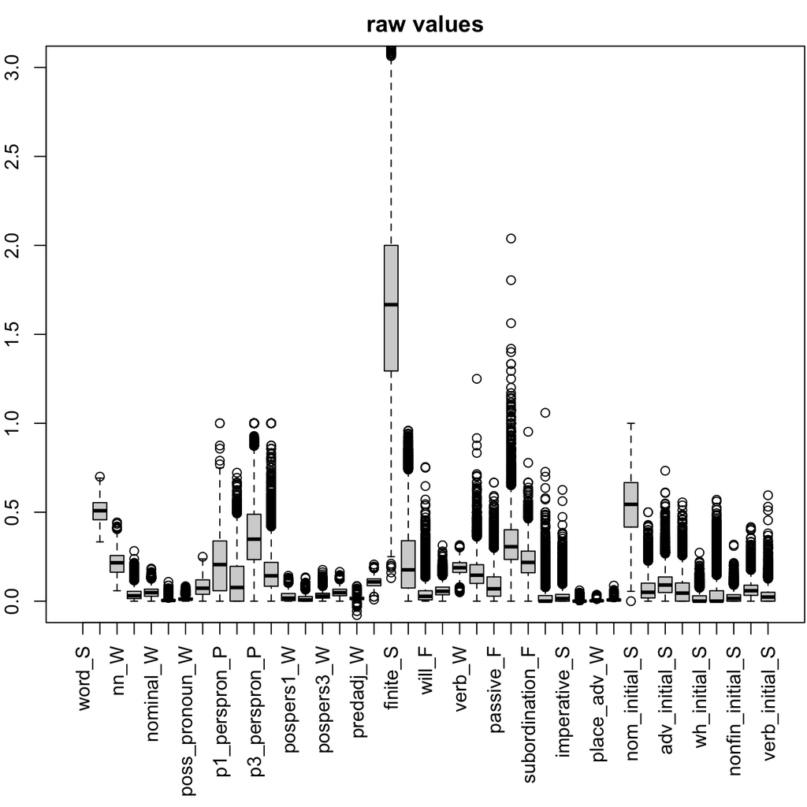

```r
par(mar=c(8,2,2,0.1))
boxplot(M, ylim=c(0,3), las=3, main="raw values")
```

```r
invisible(dev.copy2pdf(file="pdf_journal/stats_boxplot_M.pdf", out.type="cairo", width=10, height=6))
```

We therefore standardize all features to z-scores as in previous work. The distributions are still highly skewed with some extreme outliers. As an alterantive to removing very sparse feature, we apply a signed logarithmic transformation to deskew the feature distributions.

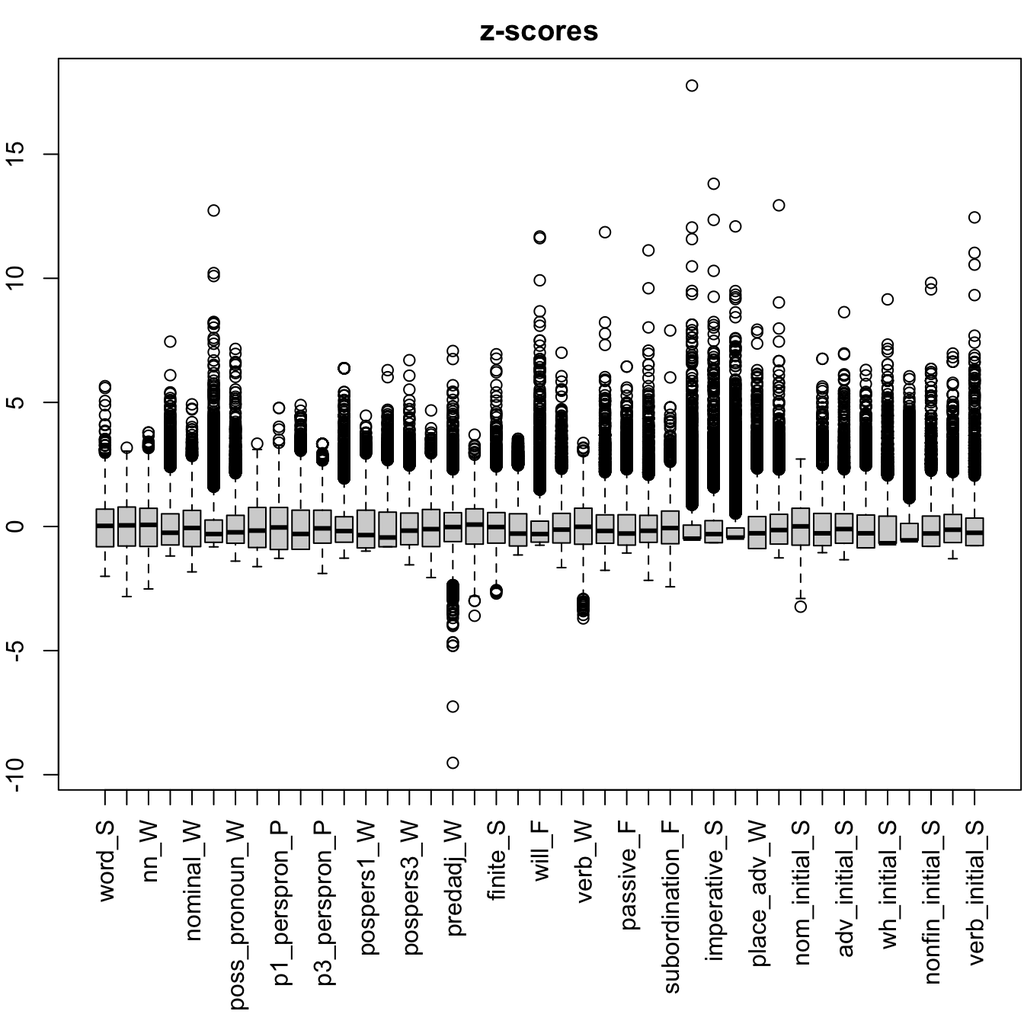

```r
Z <- scale(M)
par(mar=c(8,2,2,0.1))
boxplot(Z, las=3, main="z-scores")
```

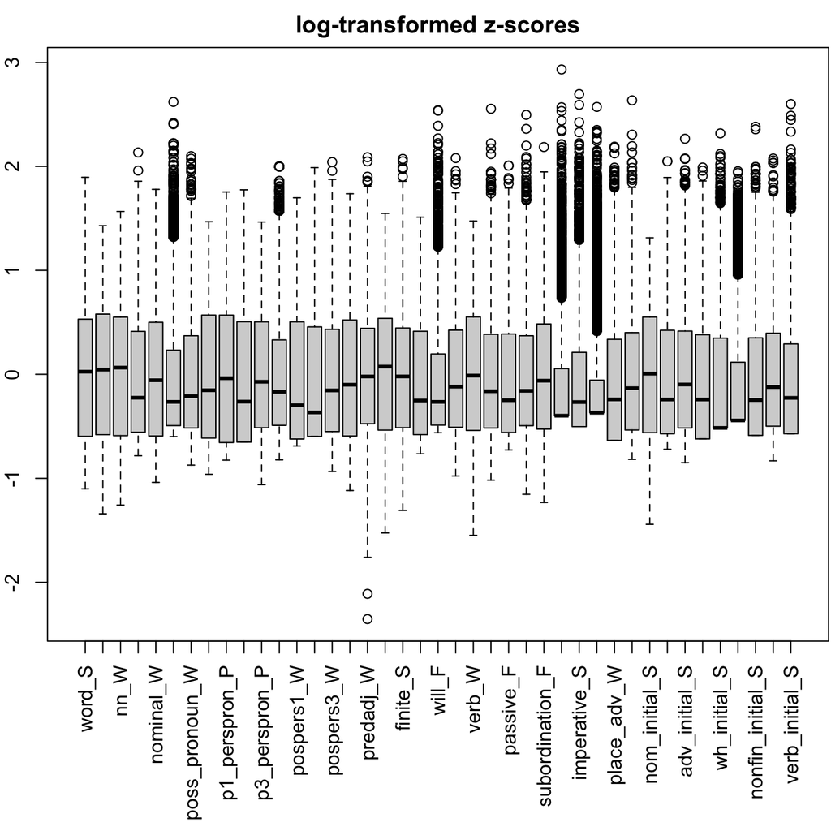

```r
invisible(dev.copy2pdf(file="pdf_journal/stats_boxplot_Z.pdf", out.type="cairo", width=10, height=6))

## signed logarithmic transformation that is smooth at 0
signed.log <- function (x, base=exp(1)) {
  sign(x) * log(1 + abs(x), base=base)
}
ZL <- signed.log(Z)
boxplot(ZL, las=3, main="log-transformed z-scores")
```

```r
invisible(dev.copy2pdf(file="pdf_journal/stats_boxplot_ZL.pdf", out.type="cairo", width=10, height=6))
```

```r
idx.3 <- Meta$shortvar %in% qw("NZ JAM HK")
res <- data.frame(
  mu3=colMeans(M[idx.3, ]),
  mu9=colMeans(M),
  mu9scale=attr(Z, "scaled:center"),
  sd3=apply(M[idx.3, ], 2, sd),
  sd9=apply(M, 2, sd),
  sd9scale=attr(Z, "scaled:scale"))
knitr::kable(res, digits=5)
```

|  | mu3 | mu9 | mu9scale | sd3 | sd9 | sd9scale |
| --- | --- | --- | --- | --- | --- | --- |
| word_S | 16.31392 | 16.11216 | 16.11216 | 6.31654 | 6.27102 | 6.27102 |
| lexical_density | 0.50841 | 0.50587 | 0.50587 | 0.06353 | 0.06113 | 0.06113 |
| nn_W | 0.21753 | 0.21193 | 0.21193 | 0.06098 | 0.06089 | 0.06089 |
| np_W | 0.03437 | 0.03884 | 0.03884 | 0.03134 | 0.03268 | 0.03268 |
| nominal_W | 0.05170 | 0.04974 | 0.04974 | 0.02838 | 0.02721 | 0.02721 |
| neoclass_W | 0.00619 | 0.00657 | 0.00657 | 0.00774 | 0.00801 | 0.00801 |
| poss_pronoun_W | 0.01373 | 0.01367 | 0.01367 | 0.01045 | 0.00980 | 0.00980 |
| pronoun_all_W | 0.07861 | 0.08139 | 0.08139 | 0.04911 | 0.05037 | 0.05037 |
| p1_perspron_P | 0.20496 | 0.21179 | 0.21179 | 0.17368 | 0.16506 | 0.16506 |
| p2_perspron_P | 0.11182 | 0.11418 | 0.11418 | 0.12728 | 0.12418 | 0.12418 |
| p3_perspron_P | 0.36901 | 0.36262 | 0.36262 | 0.20195 | 0.19165 | 0.19165 |
| it_P | 0.16588 | 0.16677 | 0.16677 | 0.13197 | 0.13071 | 0.13071 |
| pospers1_W | 0.02529 | 0.02596 | 0.02596 | 0.02782 | 0.02618 | 0.02618 |
| pospers2_W | 0.01486 | 0.01539 | 0.01539 | 0.01875 | 0.01884 | 0.01884 |
| pospers3_W | 0.03167 | 0.03300 | 0.03300 | 0.02133 | 0.02136 | 0.02136 |
| atadj_W | 0.05015 | 0.05034 | 0.05034 | 0.02442 | 0.02446 | 0.02446 |
| predadj_W | 0.01579 | 0.01571 | 0.01571 | 0.00985 | 0.00986 | 0.00986 |
| prep_W | 0.10549 | 0.10622 | 0.10622 | 0.02640 | 0.02703 | 0.02703 |
| finite_S | 1.70985 | 1.67821 | 1.67821 | 0.60051 | 0.57328 | 0.57328 |
| past_tense_F | 0.23395 | 0.23489 | 0.23489 | 0.21318 | 0.20478 | 0.20478 |
| will_F | 0.04451 | 0.04570 | 0.04570 | 0.05870 | 0.06063 | 0.06063 |
| modal_verb_V | 0.06159 | 0.06013 | 0.06013 | 0.03748 | 0.03629 | 0.03629 |
| verb_W | 0.19006 | 0.18850 | 0.18850 | 0.03629 | 0.03749 | 0.03749 |
| infinitive_F | 0.16850 | 0.16203 | 0.16203 | 0.08879 | 0.09175 | 0.09175 |
| passive_F | 0.09572 | 0.09485 | 0.09485 | 0.09044 | 0.08877 | 0.08877 |
| coordination_F | 0.32993 | 0.33263 | 0.33263 | 0.14953 | 0.15331 | 0.15331 |
| subordination_F | 0.22555 | 0.22397 | 0.22397 | 0.09190 | 0.09222 | 0.09222 |
| interrogative_S | 0.03003 | 0.02834 | 0.02834 | 0.06710 | 0.05801 | 0.05801 |
| imperative_S | 0.02899 | 0.02826 | 0.02826 | 0.04584 | 0.04325 | 0.04325 |
| title_W | 0.00233 | 0.00216 | 0.00216 | 0.00552 | 0.00484 | 0.00484 |
| place_adv_W | 0.00338 | 0.00364 | 0.00364 | 0.00407 | 0.00410 | 0.00410 |
| time_adv_W | 0.00755 | 0.00782 | 0.00782 | 0.00597 | 0.00618 | 0.00618 |
| nom_initial_S | 0.54215 | 0.54306 | 0.54306 | 0.18638 | 0.16807 | 0.16807 |
| prep_initial_S | 0.06719 | 0.06752 | 0.06752 | 0.06445 | 0.06401 | 0.06401 |
| adv_initial_S | 0.09521 | 0.09843 | 0.09843 | 0.07390 | 0.07351 | 0.07351 |
| text_initial_S | 0.06102 | 0.06665 | 0.06665 | 0.07671 | 0.07749 | 0.07749 |
| wh_initial_S | 0.01855 | 0.01872 | 0.01872 | 0.02825 | 0.02776 | 0.02776 |
| disc_initial_S | 0.05445 | 0.04814 | 0.04814 | 0.10013 | 0.08628 | 0.08628 |
| nonfin_initial_S | 0.02350 | 0.02397 | 0.02397 | 0.03036 | 0.02997 | 0.02997 |
| subord_initial_S | 0.06603 | 0.06539 | 0.06539 | 0.05283 | 0.05040 | 0.05040 |
| verb_initial_S | 0.03551 | 0.03469 | 0.03469 | 0.04837 | 0.04503 | 0.04503 |

Most of the differences seem small enough so that they should not have a substantial effect on the resulting z-scores and analysis. One indicator is to show the difference between the means in z-units, i.e. scaled by the (smaller) standard deviation.

```r
tmp <- with(
  res,
  structure((mu9 - mu3) / pmin(sd9, sd3),
            names=rownames(res)))
round(tmp, 3)
```

```
##           word_S  lexical_density             nn_W             np_W
##           -0.032           -0.042           -0.092            0.143
##        nominal_W       neoclass_W   poss_pronoun_W    pronoun_all_W
##           -0.072            0.050           -0.006            0.057
##    p1_perspron_P    p2_perspron_P    p3_perspron_P             it_P
##            0.041            0.019           -0.033            0.007
##       pospers1_W       pospers2_W       pospers3_W          atadj_W
##            0.025            0.028            0.062            0.008
##        predadj_W           prep_W         finite_S     past_tense_F
##           -0.009            0.028           -0.055            0.005
##           will_F     modal_verb_V           verb_W     infinitive_F
##            0.020           -0.040           -0.043           -0.073
##        passive_F   coordination_F  subordination_F  interrogative_S
##           -0.010            0.018           -0.017           -0.029
##     imperative_S          title_W      place_adv_W       time_adv_W
##           -0.017           -0.034            0.064            0.044
##    nom_initial_S   prep_initial_S    adv_initial_S   text_initial_S
##            0.005            0.005            0.044            0.073
##     wh_initial_S   disc_initial_S nonfin_initial_S subord_initial_S
##            0.006           -0.073            0.016           -0.013
##   verb_initial_S
##           -0.018
```

We check for collinearities and excessive correlation patterns between the features. Unfortunately adding a colour key to the plot is no longer supported.

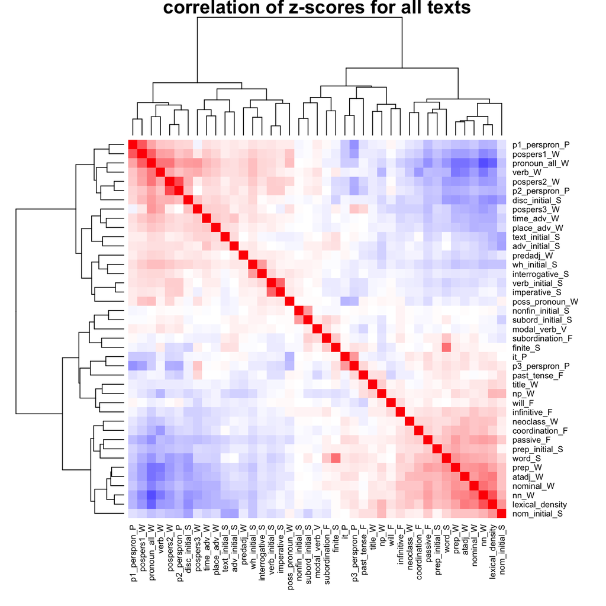

```r
fnames <- colnames(Z)
cor.colors <- diverge_hsv(101, power=1)
par(cex=.5)
hmap(cor(Z), zlim=c(-1, 1), col=cor.colors, margins=c(7, 7),
     cexRow=.8, cexCol=.8,
     main="correlation of z-scores for all texts")
```

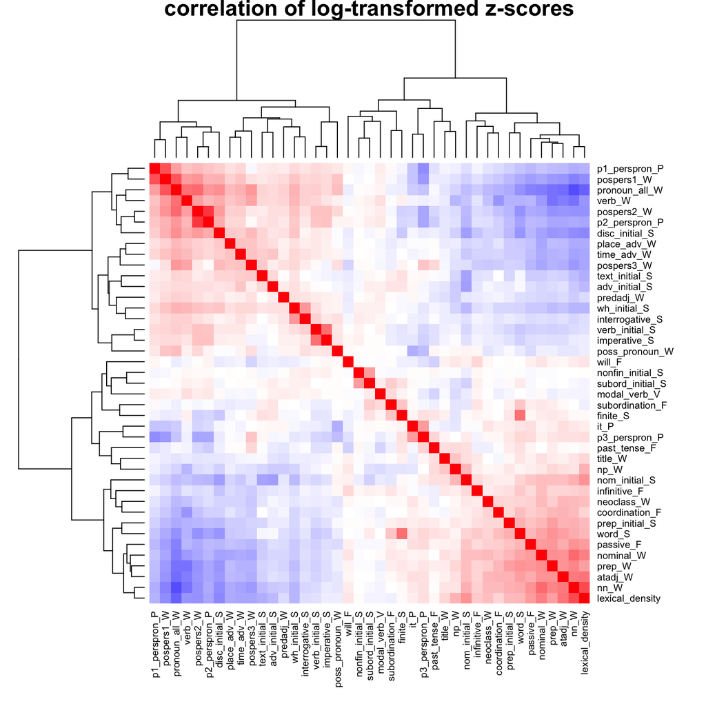

```r
invisible(dev.copy2pdf(file="pdf_journal/stats_correlation_Z.pdf", out.type="cairo"))
hmap(cor(ZL), zlim=c(-1, 1), col=cor.colors, margins=c(7, 7),
     cexRow=.8, cexCol=.8,
     main="correlation of log-transformed z-scores")
```

```r
invisible(dev.copy2pdf(file="pdf_journal/stats_correlation_ZL.pdf", out.type="cairo"))
```

The correlations look reasonable. An overall block structure is visible – which presumably corresponds to the spoken-written dimension – but the correlations within the blocks are fairly weak and the features are less directly linked to noun and verb frequency than in Biber’s analysis.

# 3 Serialize pre-processed data set

We add word and sentence counts to the metadata table, so they can be used for filtering.

```r
Meta[, word := Features$word]
Meta[, sent := Features$sent]
```

And we create nicely readable labels for the features.

```r
feature.names <-
  gsub("_+", " ",
       sub("_(\\pL)$", "/\\1",
           colnames(Z), perl=TRUE))
cat(paste(feature.names, collapse=", "), "\n")
```

[output not shown]

Finally, save all objects into a single `.rda` file. We also provide a fixed (i.e. reproducible) random ordering index for plots.

```r
set.seed(42)
rand.idx <- sample(nrow(Meta))
save(Meta, rand.idx,
     Features, M, Z, ZL,
     types.variety, types.shortvar, types.mode, types.format,
     types.textcat32, types.short32, types.code32,
     types.textcat20, types.short20, types.code20,
     types.textcat12, types.short12, types.code12,
     rainbow.32, rainbow.20, rainbow.12, feature.names,
     file="ice_preprocessed.rda")
```